# Plotting healthy life expectancy and life expectancy by deprivation for English local authorities

Seb Fox

2017-04-11

This worked example attempts to document a common workflow a user might follow when using the `fingertipsR` package.

Suppose you want to plot healthy life expectancy and life expectancy by deprivation for a given year of data that fingertips contains - you will begin by wondering *where to start*.

## Where to start

There is one function in the `fingertipsR` package that extracts data from the Fingertips API: `fingertips_data()`. This function has the following inputs:

- IndicatorID
- AreaCode
- DomainID
- ProfileID
- AreaTypeID (this defaults to 102; County and Unitary Authority)
- ParentAreaTypeID (this defaults to 6; Government Office Region)

One of *IndicatorID*, *DomainID* or *ProfileID* must be complete. *AreaCode* needs completion if you are extracting data for a particular area or group of areas only. *AreaTypeID* determines the geography to extract the data for. In this case we want County and Unitary Authority level. *ParentAreaTypeID* requires an area type code that the *AreaTypeID* maps to.

Therefore, the inputs to the `fingertips_data` function that we need to find out are the ID codes for:

- IndicatorID
- AreaTypeID
- ParentAreaTypeID

## IndicatorID

There are two indicators we are interested in for this exercise. Without consulting the [Fingertips website](https://fingertips.phe.org.uk/), we know approximately what they are called:

- Healthy life expectancy
- Life expectancy

We can use the `indicators()` function to return a list of all the indicators within Fingertips. We can then filter the name field for the term *life expectancy* (note, the IndicatorName field has been converted to lower case in the following code chunk to ensure matches will not be overlooked as a result of upper case letters).

```r
inds <- indicators()
life_expectancy <- inds[grepl("life expectancy", tolower(inds$IndicatorName)),]

# Because the same indicators are used in multiple profiles, there are many repeated indicators in this table (some with varying IndicatorName but same IndicatorID)

# This returns a record for each IndicatorID
life_expectancy <- unique(life_expectancy[duplicated(life_expectancy$IndicatorID) == FALSE,
                                          c("IndicatorID", "IndicatorName")])
knitr::kable(life_expectancy, row.names = FALSE)
```

| IndicatorID | IndicatorName |
| --- | --- |
| 90362 | Healthy life expectancy at birth: the average number of years a person would expect to live in good health based on contemporary mortality rates and prevalence of self-reported good health. (in PHOF 0… |
| 90364 | Range in years. Slope index of inequality in life expectancy at birth within local authorities, based on local (LSOA) deprivation deciles: the range in years of life expectancy across the social gradi… |
| 90366 | Life expectancy at birth: the average number of years a person would expect to live based on contemporary mortality rates. (in PHOF 0.1ii) |
| 92031 | Range in years. Slope index of inequality in healthy life expectancy within local authorities, based on deprivation within Middle Super Output Areas (MSOAs): the range in years of life expectancy acro… |
| 91102 | 0.1ii - Life expectancy at 65: the average number of years a person would expect to live based on contemporary mortality rates. |
| 90365 | 0.2iv - The gap in years between overall life expectancy at birth in each English local authority and life expectancy at birth for England as a whole. |
| 650 | Life expectancy - MSOA based |
| 90363 | 0.2i - Slope index of inequality in life expectancy at birth based on national deprivation deciles within England: the range in years of life expectancy across the social gradient, from most to least … |
| 90823 | 0.2ii - Number of upper tier local authorities for which the local slope index of inequality in life expectancy (as defined in indicator 0.2iii) has decreased |
| 90825 | 0.2v - Slope index of inequality in healthy life expectancy at birth based on national deprivation deciles within England: the range in years of life expectancy across the social gradient, from most t… |
| 91319 | 0.2vii - Slope index of inequality in life expectancy at birth within English region, based on regional deprivation deciles: the range in years of life expectancy across the social gradient within eac… |

The two indicators we are interested in from this table are:

- 90362
- 90366

## AreaTypeID

We can work out what the *AreaTypeID* codes we are interested in using the function `area_types()`. We’ve decided that we want to produce the graph at County and Unitary Authority level. From the section Where to start we need codes for *AreaTypeID* and *ParentAreaTypeID.*

```r
areaTypes <- area_types()
DT::datatable(areaTypes, filter = "top", rownames = FALSE)
```

| AreaID | AreaName | ParentAreaID | ParentAreaName |
| --- | --- | --- | --- |
| 2 | Primary Care Trust | 5 | Strategic Health Authority |
| 3 | Middle Super Output Area | 101 | Local authority districts and Unitary Authorities |
| 6 | Government Office Region | 15 | Country |
| 7 | General Practice | 19 | Clinical Commissioning Group |
| 8 | Ward | 101 | Local authority districts and Unitary Authorities |
| 19 | Clinical Commissioning Group | 46 | Sub-region (former Local area teams) |
| 19 | Clinical Commissioning Group | 112 | Strategic Clinical Network |
| 19 | Clinical Commissioning Group | 10008 | Deprivation decile |
| 19 | Clinical Commissioning Group | 110 | ONS statistical neighbour cluster - middle level |
| 19 | Clinical Commissioning Group | 10011 | CCG clusters |

[output cut: 29 more lines]

The table shows that the *AreaID* for County and Unitary Authority level is 102. The third column, *ParentAreaID*, shows the IDs of the area types that these map to. In the case of County and Unitary Authorities, these are:

| ParentAreaID | ParentAreaName |
| --- | --- |
| 6 | Government Office Region |
| 42 | 2013 PHE Regions (4) |
| 10002 | Depriv. decile (IMD 2010) |
| 10039 | Depriv. decile (IMD 2015) |
| 103 | PHEC 2013 only plus PHEC unchanged |
| 104 | PHEC 2015 new plus PHEC 2013 unchanged |
| 126 | Combined authorities |

*ParentAreaID* is 6 by default for the `fingertips_data()` function, so we can stick with that.

## Deprivation

We want to plot life expectancy against deprivation information. The package has a `deprivation_deciles()` function that allows us to return this information. This is populated from the CIPFA Indices of Multiple Deprivation (IMD). Note, there is only information for upper and lower tier local authorities (*AreaTypeID* = 102 and 101 respectively). IMD has only been produced for the years 2010 and 2015.

```r
dep <- deprivation_decile(AreaTypeID = 102, Year = 2015)
DT::datatable(dep, filter = "top", rownames = FALSE)
```

| AreaCode | IMDscore | decile |
| --- | --- | --- |
| E06000001 | 33.178 | 2 |
| E06000002 | 40.216 | 1 |
| E06000003 | 28.567 | 3 |
| E06000004 | 24.625 | 5 |
| E06000005 | 23.639 | 5 |
| E06000006 | 31.943 | 2 |
| E06000007 | 19.312 | 7 |
| E06000008 | 34.189 | 1 |
| E06000009 | 41.997 | 1 |
| E06000010 | 41.235 | 1 |

[output cut: 142 more lines]

## Extracting the data

Finally, we can use the `fingertips_data()` function with the inputs we have determined previously.

```r
indicators <- c(90362, 90366)
data <- fingertips_data(IndicatorID = indicators,
                        AreaTypeID = 102)

pander::pandoc.table(tail(data),
                     style="rmarkdown",
                     split.tables = 90,
                     keep.line.breaks = TRUE)
```

```
##
##
## |   &nbsp;   |  IndicatorID  |              IndicatorName              |  ParentCode  |
## |:----------:|:-------------:|:---------------------------------------:|:------------:|
## |  **7511**  |     90362     | 0.1i - Healthy life expectancy at birth |  E12000005   |
## |  **7512**  |     90362     | 0.1i - Healthy life expectancy at birth |  E12000006   |
## |  **7513**  |     90362     | 0.1i - Healthy life expectancy at birth |  E12000008   |
## |  **7514**  |     90362     | 0.1i - Healthy life expectancy at birth |  E12000005   |
## |  **7515**  |     90362     | 0.1i - Healthy life expectancy at birth |  E12000008   |
## |  **7516**  |     90362     | 0.1i - Healthy life expectancy at birth |  E12000005   |
##
## Table: Table continues below
##
##
##
## |   &nbsp;   |       ParentName       |  AreaCode  |    AreaName    |  AreaType   |
## |:----------:|:----------------------:|:----------:|:--------------:|:-----------:|
## |  **7511**  |  West Midlands region  | E10000028  | Staffordshire  | County & UA |
## |  **7512**  | East of England region | E10000029  |    Suffolk     | County & UA |
## |  **7513**  |   South East region    | E10000030  |     Surrey     | County & UA |
## |  **7514**  |  West Midlands region  | E10000031  |  Warwickshire  | County & UA |
## |  **7515**  |   South East region    | E10000032  |  West Sussex   | County & UA |
## |  **7516**  |  West Midlands region  | E10000034  | Worcestershire | County & UA |
##
## Table: Table continues below
##
##
##
## |   &nbsp;   |  Sex   |   Age    |  CategoryType  |  Category  |  Timeperiod  |
## |:----------:|:------:|:--------:|:--------------:|:----------:|:------------:|
## |  **7511**  | Female | All ages |                |            |  2013 - 15   |
## |  **7512**  | Female | All ages |                |            |  2013 - 15   |
## |  **7513**  | Female | All ages |                |            |  2013 - 15   |
## |  **7514**  | Female | All ages |                |            |  2013 - 15   |
## |  **7515**  | Female | All ages |                |            |  2013 - 15   |
## |  **7516**  | Female | All ages |                |            |  2013 - 15   |
##
## Table: Table continues below
##
##
```

[output cut: 33 more lines]

```
## |  **7515**  |                Better                 |
## |  **7516**  |                Better                 |
##
## Table: Table continues below
##
##
##
## |   &nbsp;   |  Comparedtosubnationalparentvalueorpercentiles  |
## |:----------:|:-----------------------------------------------:|
## |  **7511**  |                      Same                       |
## |  **7512**  |                      Same                       |
## |  **7513**  |                     Better                      |
## |  **7514**  |                     Better                      |
## |  **7515**  |                      Same                       |
## |  **7516**  |                     Better                      |
```

The data frame returned by `fingertips_data()` contains 21 variables. For this exercise, we are only interested in a few of them:

- IndicatorID
- AreaCode
- Sex
- Timeperiod
- Value

```r
cols <- c("IndicatorID", "AreaCode", "Sex", "Timeperiod", "Value")
data <- data[data$AreaType == "County & UA" & data$Timeperiod == "2012 - 14", cols]

# merge deprivation onto data
data <- merge(data, dep, by.x = "AreaCode", by.y = "AreaCode", all.x = TRUE)

# remove NA values
data <- data[complete.cases(data),]
DT::datatable(data, filter = "top", rownames = FALSE)
```

| AreaCode | IndicatorID | Sex | Timeperiod | Value | IMDscore | decile |
| --- | --- | --- | --- | --- | --- | --- |
| E06000001 | 90366 | Male | 2012 - 14 | 77.57901 | 33.178 | 2 |
| E06000001 | 90366 | Female | 2012 - 14 | 81.63225 | 33.178 | 2 |
| E06000001 | 90362 | Male | 2012 - 14 | 55.84105 | 33.178 | 2 |
| E06000001 | 90362 | Female | 2012 - 14 | 57.22452 | 33.178 | 2 |
| E06000002 | 90366 | Female | 2012 - 14 | 79.82811 | 40.216 | 1 |
| E06000002 | 90362 | Male | 2012 - 14 | 57.88595 | 40.216 | 1 |
| E06000002 | 90362 | Female | 2012 - 14 | 61.18368 | 40.216 | 1 |
| E06000002 | 90366 | Male | 2012 - 14 | 76.17041 | 40.216 | 1 |
| E06000003 | 90366 | Female | 2012 - 14 | 81.94374 | 28.567 | 3 |
| E06000003 | 90362 | Male | 2012 - 14 | 60.22083 | 28.567 | 3 |

[output cut: 590 more lines]

## Plotting outputs

Using `ggplot2` it is possible to plot the outputs

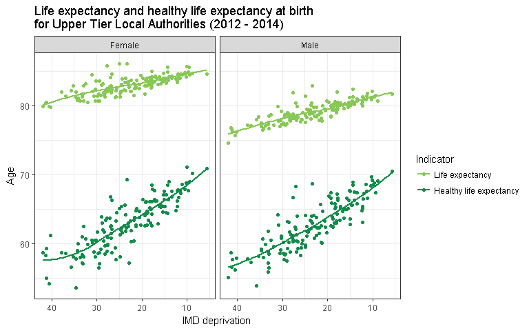

```r
p <- ggplot(data, aes(x = IMDscore, y = Value, col = factor(IndicatorID)))
p <- p +
        geom_point() +
        geom_smooth(se = FALSE, method = "loess") +
        facet_wrap(~ Sex) +
        scale_colour_manual(name = "Indicator",
                            breaks = c("90366", "90362"),
                            labels = c("Life expectancy", "Healthy life expectancy"),
                            values = c("#128c4a", "#88c857")) +
        scale_x_reverse() +
        labs(x = "IMD deprivation",
             y = "Age",
             title = "Life expectancy and healthy life expectancy at birth \nfor Upper Tier Local Authorities (2012 - 2014)") +
        theme_bw()
print(p)
```